# Conceptos básicos

Author

NA Cruz

# PRÁCTICA 1 — Estadística Descriptiva

## Contexto del estudio

La calidad del agua es un elemento clave para la conservación de los ecosistemas acuáticos y para la gestión ambiental en Mallorca. La isla presenta una gran diversidad de ambientes hídricos:

- Torrentes de la Serra de Tramuntana
- Zonas agrícolas del Pla
- Áreas urbanas como Palma
- Zonas húmedas como s’Albufera
- Áreas costeras

En este estudio, el Consell de Mallorca ha realizado una campaña de muestreo con el objetivo de evaluar el estado ecológico del agua en diferentes puntos de la isla.

Se han recogido **500 muestras de agua**, cada una correspondiente a una medición puntual realizada en un lugar y momento determinado.

En cada muestra se han medido los siguientes parámetros:

- pH
- Temperatura (°C)
- Turbidez (NTU)
- Oxígeno disuelto (mg/L)
- Conductividad (µS/cm)

Además, se han clasificado las muestras según:

- Tipo de zona
- Uso del suelo
- Temporada
- Estado ecológico
- Riesgo de eutrofización
- Presión antrópica

# Objetivos de la práctica

1. Comprender la diferencia entre **población y muestra**
2. Analizar cómo se realiza un **proceso de muestreo**
3. Identificar y clasificar los **tipos de variables**
4. Interpretar los datos desde un punto de vista ambiental

# 1. Población y muestra

## A. Definición conceptual

1. ¿Cuál sería la **población estadística** en este estudio?
2. ¿Qué representa la **muestra** utilizada?
3. ¿Son lo mismo “500 muestras de agua” que “500 lugares de Mallorca”? Justifica.

## B. Diseño de muestreo

Supongamos que las muestras se tomaron:

- En 5 tipos de zona
- Durante las 4 estaciones del año
- Con puntos seleccionados de forma aleatoria dentro de cada zona
1. ¿Qué tipo de muestreo se ha realizado?
   - Aleatorio simple
   - Estratificado
   - Sistemático
   - Por conveniencia
2. ¿Por qué es importante que el muestreo esté bien distribuido espacial y temporalmente?
3. ¿Qué sesgos podrían aparecer si solo se muestreara en verano?

# 3. Gráficas y tablas

```r
library(tidyverse)
Water <- read_csv("https://raw.githubusercontent.com/atobar-uib/MAT_II_BIO_BIOQ_UIB/refs/heads/main/Datasets/WaterQualityTesting.csv")
```

```
──────────────────────────────────────────────────────── Delimiter: "," chr
(6): Tipo_de_Zona, Uso_del_Suelo, Temporada, Estado_Ecológico, Riesgo_Eu... dbl
(7): ...1, Sample ID, pH, Temperature (°C), Turbidity (NTU), Dissolved O...
```

### Tabla de frecuencias

Vamos a ver la frecuencia de **Tipo_de_Zona**:

```r
freq_tipo <- Water %>%
  count(Tipo_de_Zona) %>%
  arrange(desc(n))

freq_tipo
```

```
# A tibble: 5 × 2
  Tipo_de_Zona            n
  <chr>               <int>
1 Serra de Tramuntana   130
2 Pla agrícola          121
3 Zona urbana            96
4 Costa                  93
5 Zona húmeda            60
```

### Diagrama de barras

Visualizamos la cantidad de muestras por **Uso_del_Suelo** con colores personalizados:

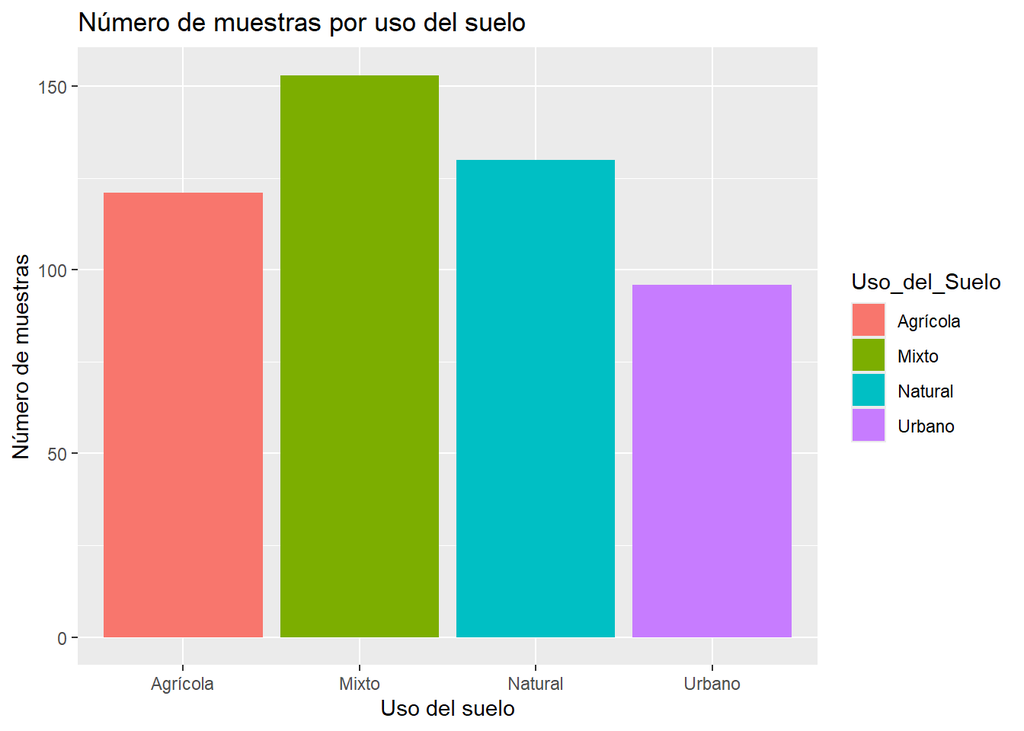

```r
ggplot(Water, aes(x = Uso_del_Suelo, fill = Uso_del_Suelo)) +
  geom_bar() +
  labs(
    title = "Número de muestras por uso del suelo",
    x = "Uso del suelo",
    y = "Número de muestras"
  )
```

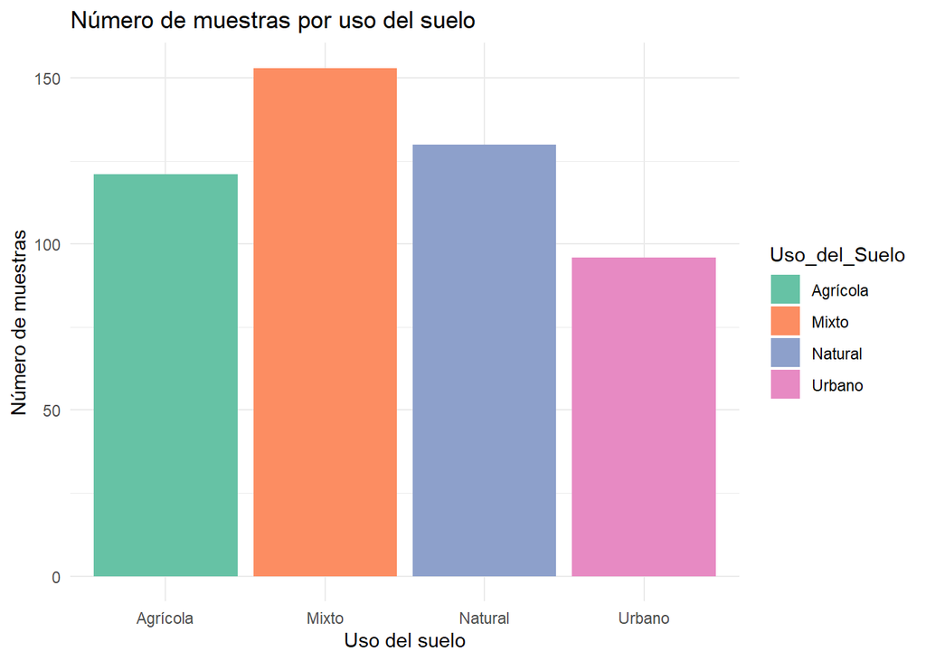

```r
ggplot(Water, aes(x = Uso_del_Suelo, fill = Uso_del_Suelo)) +
  geom_bar() +
  scale_fill_brewer(palette = "Set2") +
  labs(
    title = "Número de muestras por uso del suelo",
    x = "Uso del suelo",
    y = "Número de muestras"
  ) +
  theme_minimal()
```

Con dos variables

```r
tabla_cont <- table(Water$Tipo_de_Zona, Water$Estado_Ecológico)
tabla_cont
```

```
                      Bueno Deficiente Moderado Muy bueno
  Costa                  59          0        4        30
  Pla agrícola           86          1        8        26
  Serra de Tramuntana    91          0        7        32
  Zona húmeda            39          0        0        21
  Zona urbana            63          0        5        28
```

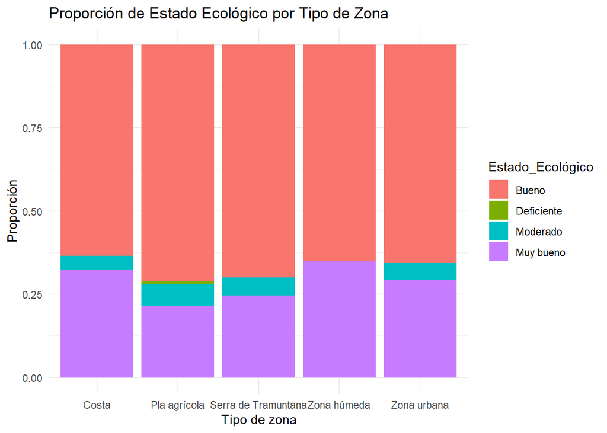

```r
ggplot(Water, aes(x = Tipo_de_Zona, fill = Estado_Ecológico)) +
  geom_bar(position = "fill") +
  labs(title = "Proporción de Estado Ecológico por Tipo de Zona",
       x = "Tipo de zona",
       y = "Proporción") +
  theme_minimal()
```

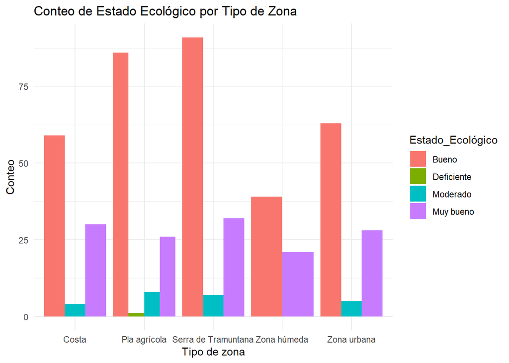

```r
ggplot(Water, aes(x = Tipo_de_Zona, fill = Estado_Ecológico)) +
  geom_bar(position = "dodge") +
  labs(title = "Conteo de Estado Ecológico por Tipo de Zona",
       x = "Tipo de zona",
       y = "Conteo") +
  theme_minimal()
```

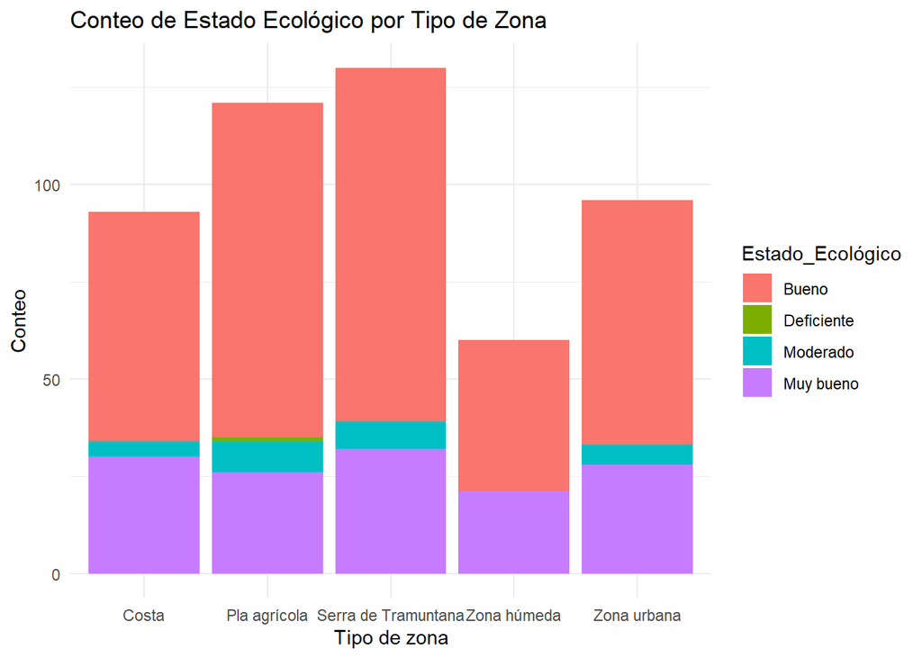

```r
ggplot(Water, aes(x = Tipo_de_Zona, fill = Estado_Ecológico)) +
  geom_bar(position = "stack") +
  labs(title = "Conteo de Estado Ecológico por Tipo de Zona",
       x = "Tipo de zona",
       y = "Conteo") +
  theme_minimal()
```

### Gráfico de sectores circulares (Pie chart)

Proporción de muestras por **Estado_Ecológico**:

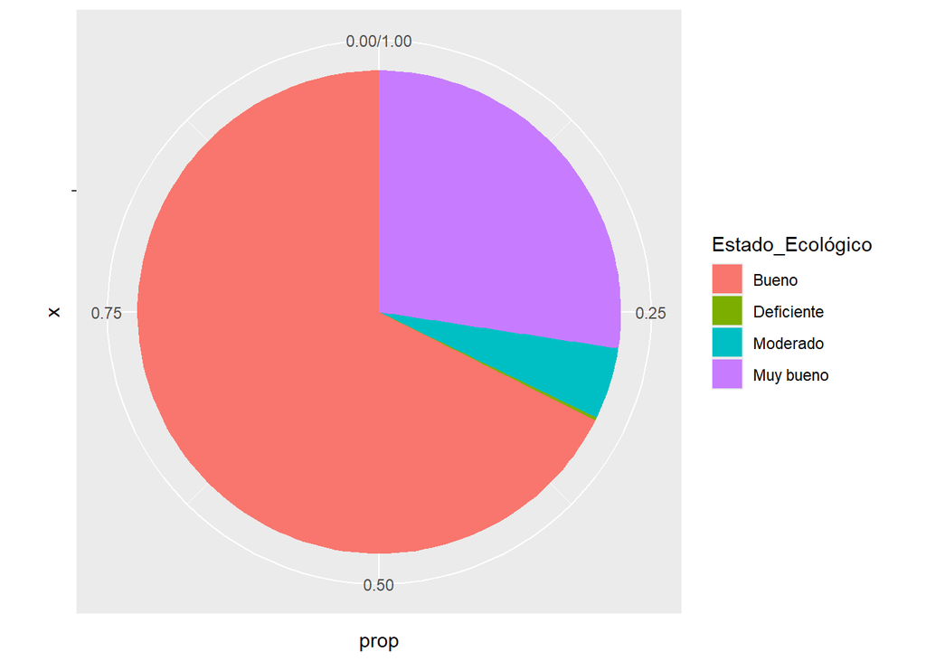

```r
estado_counts <- Water %>%
  count(Estado_Ecológico) %>%
  mutate(prop = n / sum(n),
         label = paste0(Estado_Ecológico, " (", n, ")"))

ggplot(estado_counts, aes(x = "", y = prop, fill = Estado_Ecológico)) +
  geom_bar(stat = "identity", width = 1) +
  coord_polar("y")
```

```r
  labs(
    title = "Proporción de muestras por Estado Ecológico"
  )
```

```
<ggplot2::labels> List of 1
 $ title: chr "Proporción de muestras por Estado Ecológico"
```

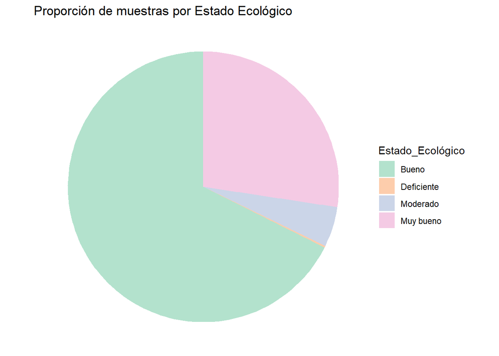

```r
ggplot(estado_counts, aes(x = "", y = prop, fill = Estado_Ecológico)) +
  geom_bar(stat = "identity", width = 1) +
  coord_polar("y") +
  scale_fill_brewer(palette = "Pastel2") +
  labs(
    title = "Proporción de muestras por Estado Ecológico"
  ) +
  theme_void()
```

### Boxplot

Distribución de **Dissolved Oxygen (mg/L)** por **Tipo_de_Zona**:

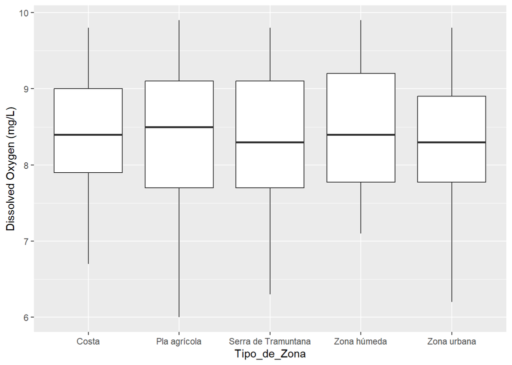

```r
ggplot(Water, aes(x = Tipo_de_Zona, y = `Dissolved Oxygen (mg/L)`)) +
  geom_boxplot()
```

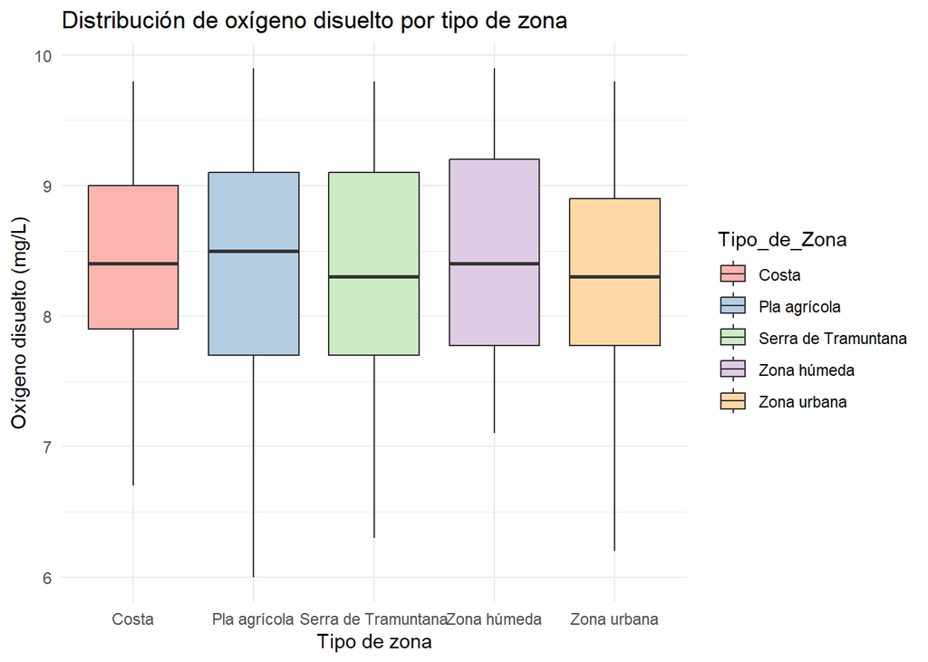

```r
ggplot(Water, aes(x = Tipo_de_Zona, y = `Dissolved Oxygen (mg/L)`, fill = Tipo_de_Zona)) +
  geom_boxplot() +
  scale_fill_brewer(palette = "Pastel1") +
  labs(
    title = "Distribución de oxígeno disuelto por tipo de zona",
    x = "Tipo de zona",
    y = "Oxígeno disuelto (mg/L)"
  ) +
  theme_minimal()
```

### Gráfico de dispersión

Relación entre **Turbidez (NTU)** y **Dissolved Oxygen (mg/L)**, coloreado por **Riesgo_Eutrofización**:

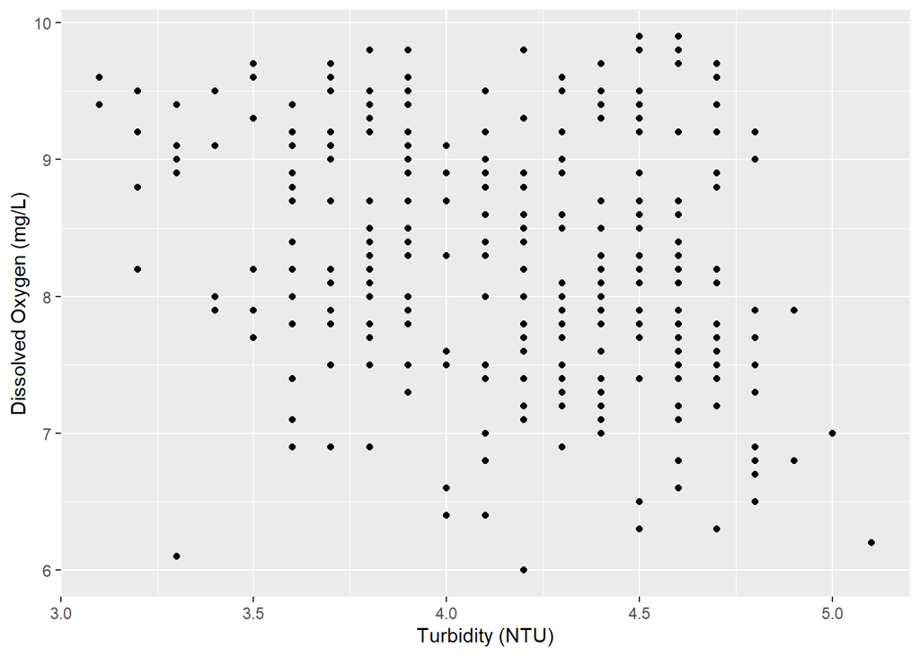

```r
ggplot(Water, aes(x = `Turbidity (NTU)`, y = `Dissolved Oxygen (mg/L)`)) +
  geom_point()
```

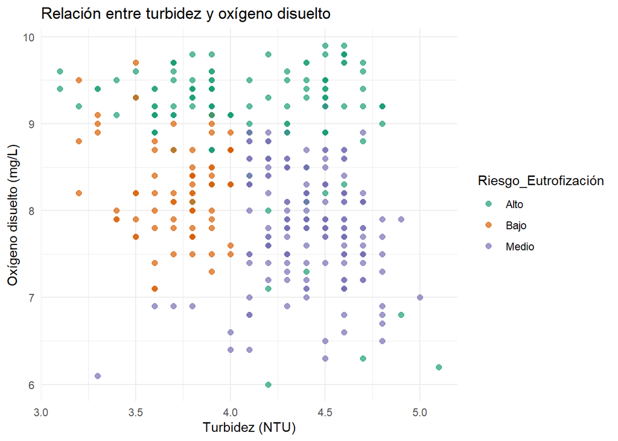

```r
ggplot(Water, aes(x = `Turbidity (NTU)`, y = `Dissolved Oxygen (mg/L)`, color = Riesgo_Eutrofización)) +
  geom_point(alpha = 0.7, size = 2) +
  scale_color_brewer(palette = "Dark2") +
  labs(
    title = "Relación entre turbidez y oxígeno disuelto",
    x = "Turbidez (NTU)",
    y = "Oxígeno disuelto (mg/L)"
  ) +
  theme_minimal()
```

### Histogramas de variables continuas

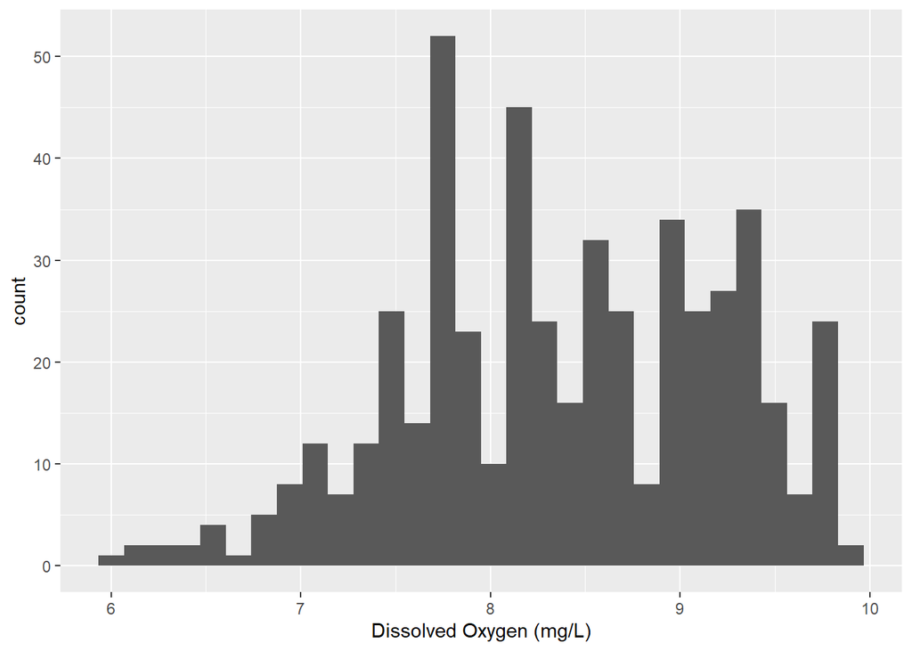

```r
ggplot(Water, aes(x = `Dissolved Oxygen (mg/L)`)) +
  geom_histogram()
```

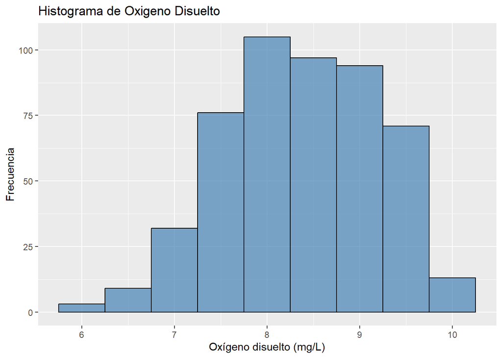

```r
ggplot(Water, aes(x =`Dissolved Oxygen (mg/L)`)) +
      geom_histogram(binwidth = 0.5, fill = "steelblue",
                     color = "black", alpha = 0.7) +
      labs(title = paste("Histograma de Oxigeno Disuelto"),
           x = "Oxígeno disuelto (mg/L)" ,
           y = "Frecuencia")
```